# Personalized Healthcare Laboratory

# Personalized Healthcare Laboratory

## Load Packages

```r
pacman::p_load(mlr3, mlr3proba, mlr3pipelines,
               mlr3learners, mlr3viz,mlr3tuning,
               mlr3benchmark, mlr3misc, mlr3extralearners,
               R6, data.table, lgr, uuid, mlbench, digest,
               backports, checkmate, paradox, reticulate,
               keras, devtools, survival, rms, summarytools, knitr)
```

[output not shown]

This function is a wrapper for library and require. It checks to see if a package is installed, if not it attempts to install the package from CRAN and/or any other repository in the pacman repository list.

Then we install the required packages and import into environvment.

```r
install_github("binderh/CoxBoost")
```

```
Skipping install of 'CoxBoost' from a github remote, the SHA1 (1dc47d70) has not changed since last install.
  Use `force = TRUE` to force installation
```

In particular we install: * **CoxBoost** : This package provides routines for fitting Cox models by likelihood based boosting for a single endpoint or in presence of competing risks. * **mlr3verse** : This package is intended to simplify both installation and loading of packages from the mlr3 ecosystem. Instead of depending on the extension packages, functions required for data analysis are re-exported, providing a thin view on the most important functionality of the mlr3 ecosystem. * **mlr3extralearners** : mlr3extralearners contains all learners from mlr3 that are not in mlr3learners or the core packages. mlr3extralearners contains helper functions to find where all the learners, across the mlr3verse, live and to install required packages to run these learners. See the interactive learner list for the full list of learners in the mlr3verse and the learner status page for a live build status. * **mlr3proba** : mlr3proba is a machine learning toolkit for making probabilistic predictions within the mlr3 ecosystem. It currently supports the tasks of Probabilistic supervised regression, Predictive survival analysis, Unconditional distribution estimation.

## Load Dataset

```r
gbcs <- mlr3proba::gbcs

gbcs2 <- gbcs[,c(5:12,15:16)]
summarytools::dfSummary(gbcs2,
                        graph.col = F,
                        valid.col = F
)
```

```
Data Frame Summary
gbcs2
Dimensions: 686 x 10
Duplicates: 0

--------------------------------------------------------------------------------
No   Variable      Stats / Values                Freqs (% of Valid)    Missing
---- ------------- ----------------------------- --------------------- ---------
1    age           Mean (sd) : 53.1 (10.1)       54 distinct values    0
     [numeric]     min < med < max:                                    (0.0%)
                   21 < 53 < 80
                   IQR (CV) : 15 (0.2)

2    menopause     Min  : 1                      1 : 290 (42.3%)       0
     [integer]     Mean : 1.6                    2 : 396 (57.7%)       (0.0%)
                   Max  : 2

3    hormone       Min  : 1                      1 : 440 (64.1%)       0
     [integer]     Mean : 1.4                    2 : 246 (35.9%)       (0.0%)
                   Max  : 2

4    size          Mean (sd) : 29.3 (14.3)       58 distinct values    0
     [numeric]     min < med < max:                                    (0.0%)
                   3 < 25 < 120
                   IQR (CV) : 15 (0.5)

5    grade         Mean (sd) : 2.1 (0.6)         1 :  81 (11.8%)       0
     [integer]     min < med < max:              2 : 444 (64.7%)       (0.0%)
                   1 < 2 < 3                     3 : 161 (23.5%)
                   IQR (CV) : 0 (0.3)

6    nodes         Mean (sd) : 5 (5.5)           30 distinct values    0
     [integer]     min < med < max:                                    (0.0%)
                   1 < 3 < 51
                   IQR (CV) : 6 (1.1)

7    prog_recp     Mean (sd) : 110 (202.3)       242 distinct values   0
     [numeric]     min < med < max:                                    (0.0%)
                   0 < 32.5 < 2380
                   IQR (CV) : 124.8 (1.8)

8    estrg_recp    Mean (sd) : 96.3 (153.1)      244 distinct values   0
     [numeric]     min < med < max:                                    (0.0%)
                   0 < 36 < 1144
                   IQR (CV) : 106 (1.6)

9    survtime      Mean (sd) : 1320.6 (619.2)    574 distinct values   0
     [numeric]     min < med < max:                                    (0.0%)
                   8 < 1338 < 2668
                   IQR (CV) : 1026 (0.5)

10   censdead      Min  : 0                      0 : 515 (75.1%)       0
     [integer]     Mean : 0.2                    1 : 171 (24.9%)       (0.0%)
                   Max  : 1
--------------------------------------------------------------------------------
```

```r
head(gbcs) # print example
```

|  | id | diagdate | recdate | deathdate | age | menopause | hormone | size | grade | nodes | prog_recp | estrg_recp | rectime | censrec | survtime | censdead |
| --- | --- | --- | --- | --- | --- | --- | --- | --- | --- | --- | --- | --- | --- | --- | --- | --- |
| 1 | 1 | 1984-08-17 | 1988-04-15 | 1990-11-16 | 38 | 1 | 1 | 18 | 3 | 5 | 141 | 105 | 1337 | 1 | 2282 | 0 |
| 2 | 2 | 1985-04-25 | 1989-03-15 | 1990-10-22 | 52 | 1 | 1 | 20 | 1 | 1 | 78 | 14 | 1420 | 1 | 2006 | 0 |
| 3 | 3 | 1984-10-11 | 1988-04-12 | 1988-10-06 | 47 | 1 | 1 | 30 | 2 | 1 | 422 | 89 | 1279 | 1 | 1456 | 1 |
| 4 | 4 | 1984-06-29 | 1984-11-24 | 1984-11-24 | 40 | 1 | 1 | 24 | 1 | 3 | 25 | 11 | 148 | 0 | 148 | 0 |
| 5 | 5 | 1984-07-03 | 1989-08-09 | 1989-08-09 | 64 | 2 | 2 | 19 | 2 | 1 | 19 | 9 | 1863 | 0 | 1863 | 0 |
| 6 | 6 | 1984-07-24 | 1989-11-08 | 1989-11-08 | 49 | 2 | 2 | 56 | 1 | 3 | 356 | 64 | 1933 | 0 | 1933 | 0 |

## Data Cleaning

```r
gbcs2$age <- scale(gbcs2$age)
gbcs2$menopause <- gbcs2$menopause-1
gbcs2$hormone <- gbcs2$hormone-1
gbcs2$size <- scale(gbcs2$size)
gbcs2$grade1 <- ifelse(gbcs2$grade==1, 1,0)
gbcs2$grade2 <- ifelse(gbcs2$grade==2, 1,0)
gbcs2$grade3 <- ifelse(gbcs2$grade==3, 1,0)
gbcs2$grade <- NULL
gbcs2$nodes <- scale(gbcs2$nodes)
gbcs2$prog_recp <- scale(gbcs2$prog_recp)
gbcs2$estrg_recp <- scale(gbcs2$estrg_recp)
```

We perform some preliminary operations of data cleaning on the dataset: * scale is generic function whose default method centers and/or scales the columns of a numeric matrix. We apply that to age, size, nodes, prog_recp and estrg_recp attributes. * create a boolean attribute for the grade of tumor (1, 2, 3) then set to null the original attribute * change values for boolean attributes menopause, hormone (just for convenience purposes).

```r
set.seed(123)
train_set = sample(nrow(gbcs2), 0.8 * nrow(gbcs2))
#str(train_set)
test_set = setdiff(seq_len(nrow(gbcs2)), train_set)

## train/test set initialization and summary

train_gbcs <- gbcs2[train_set, ]
summarytools::dfSummary(train_gbcs,
                        graph.col = F,
                        valid.col = F
)
```

```
Data Frame Summary
train_gbcs
Dimensions: 548 x 12
Duplicates: 0

------------------------------------------------------------------------------------
No   Variable          Stats / Values                Freqs (% of Valid)    Missing
---- ----------------- ----------------------------- --------------------- ---------
1    age               Mean (sd) : 0 (1)             50 distinct values    0
     [matrix, array]   min < med < max:                                    (0.0%)
                       -2.8 < -0.1 < 2.7
                       IQR (CV) : 1.5 (-43)

2    menopause         Min  : 0                      0 : 238 (43.4%)       0
     [numeric]         Mean : 0.6                    1 : 310 (56.6%)       (0.0%)
                       Max  : 1

3    hormone           Min  : 0                      0 : 352 (64.2%)       0
     [numeric]         Mean : 0.4                    1 : 196 (35.8%)       (0.0%)
                       Max  : 1

4    size              Mean (sd) : 0 (1)             54 distinct values    0
     [matrix, array]   min < med < max:                                    (0.0%)
                       -1.8 < -0.3 < 6.3
                       IQR (CV) : 1 (-64.2)

5    nodes             Mean (sd) : 0 (1)             29 distinct values    0
     [matrix, array]   min < med < max:                                    (0.0%)
                       -0.7 < -0.4 < 8.4
                       IQR (CV) : 1.1 (-124.3)

6    prog_recp         Mean (sd) : 0 (1.1)           214 distinct values   0
     [matrix, array]   min < med < max:                                    (0.0%)
                       -0.5 < -0.4 < 11.2
                       IQR (CV) : 0.6 (56.3)

7    estrg_recp        Mean (sd) : 0 (1)             217 distinct values   0
     [matrix, array]   min < med < max:                                    (0.0%)
                       -0.6 < -0.4 < 6.8
                       IQR (CV) : 0.7 (87.2)

8    survtime          Mean (sd) : 1321.2 (613.4)    467 distinct values   0
     [numeric]         min < med < max:                                    (0.0%)
                       8 < 1338 < 2668
                       IQR (CV) : 994.8 (0.5)

9    censdead          Min  : 0                      0 : 416 (75.9%)       0
     [integer]         Mean : 0.2                    1 : 132 (24.1%)       (0.0%)
                       Max  : 1

10   grade1            Min  : 0                      0 : 481 (87.8%)       0
     [numeric]         Mean : 0.1                    1 :  67 (12.2%)       (0.0%)
                       Max  : 1

11   grade2            Min  : 0                      0 : 197 (35.9%)       0
     [numeric]         Mean : 0.6                    1 : 351 (64.1%)       (0.0%)
                       Max  : 1

12   grade3            Min  : 0                      0 : 418 (76.3%)       0
     [numeric]         Mean : 0.2                    1 : 130 (23.7%)       (0.0%)
                       Max  : 1
------------------------------------------------------------------------------------
```

```r
test_gbcs <- gbcs2[test_set, ]
summarytools::dfSummary(test_gbcs,
                        graph.col = F,
                        valid.col = F
)
```

```
Data Frame Summary
test_gbcs
Dimensions: 138 x 12
Duplicates: 0

------------------------------------------------------------------------------------
No   Variable          Stats / Values                Freqs (% of Valid)    Missing
---- ----------------- ----------------------------- --------------------- ---------
1    age               Mean (sd) : 0.1 (1)           40 distinct values    0
     [matrix, array]   min < med < max:                                    (0.0%)
                       -3.2 < 0 < 2.4
                       IQR (CV) : 1.4 (10.5)

2    menopause         Min  : 0                      0 : 52 (37.7%)        0
     [numeric]         Mean : 0.6                    1 : 86 (62.3%)        (0.0%)
                       Max  : 1

3    hormone           Min  : 0                      0 : 88 (63.8%)        0
     [numeric]         Mean : 0.4                    1 : 50 (36.2%)        (0.0%)
                       Max  : 1

4    size              Mean (sd) : 0.1 (1)           44 distinct values    0
     [matrix, array]   min < med < max:                                    (0.0%)
                       -1.8 < -0.1 < 3.4
                       IQR (CV) : 1.2 (16.5)

5    nodes             Mean (sd) : 0 (0.9)           20 distinct values    0
     [matrix, array]   min < med < max:                                    (0.0%)
                       -0.7 < -0.3 < 5.7
                       IQR (CV) : 0.9 (28.4)

6    prog_recp         Mean (sd) : -0.1 (0.8)        89 distinct values    0
     [matrix, array]   min < med < max:                                    (0.0%)
                       -0.5 < -0.4 < 3.7
                       IQR (CV) : 0.6 (-10.3)

7    estrg_recp        Mean (sd) : 0 (0.9)           85 distinct values    0
     [matrix, array]   min < med < max:                                    (0.0%)
                       -0.6 < -0.4 < 6.5
                       IQR (CV) : 0.6 (-20.3)

8    survtime          Mean (sd) : 1318.4 (644.2)    133 distinct values   0
     [numeric]         min < med < max:                                    (0.0%)
                       16 < 1331.5 < 2612
                       IQR (CV) : 1097.8 (0.5)

9    censdead          Min  : 0                      0 : 99 (71.7%)        0
     [integer]         Mean : 0.3                    1 : 39 (28.3%)        (0.0%)
                       Max  : 1

10   grade1            Min  : 0                      0 : 124 (89.9%)       0
     [numeric]         Mean : 0.1                    1 :  14 (10.1%)       (0.0%)
                       Max  : 1

11   grade2            Min  : 0                      0 : 45 (32.6%)        0
     [numeric]         Mean : 0.7                    1 : 93 (67.4%)        (0.0%)
                       Max  : 1

12   grade3            Min  : 0                      0 : 107 (77.5%)       0
     [numeric]         Mean : 0.2                    1 :  31 (22.5%)       (0.0%)
                       Max  : 1
------------------------------------------------------------------------------------
```

**set.seed** is a function that permits to probabilistic/random processes such as estimation to be reproduced in a deterministic way. So for reproducibilty of the experiment and of our result we set it to a fixed integer value (123). **sample** function takes a sample of the specified size from the elements of gbcs2 without replacement (default).

In the end we print 2 summaries of the characteristics of the train and test dataset.

## Analysis

### Cox Model

```r
fit <- coxph(Surv(survtime, censdead) ~ age + menopause + hormone + size + grade1 + grade2 + nodes + prog_recp + estrg_recp, data = train_gbcs)
summary(fit)
```

```
Call:
coxph(formula = Surv(survtime, censdead) ~ age + menopause +
    hormone + size + grade1 + grade2 + nodes + prog_recp + estrg_recp,
    data = train_gbcs)

  n= 548, number of events= 132

               coef exp(coef) se(coef)      z Pr(>|z|)
age         0.15550   1.16825  0.14199  1.095  0.27345
menopause  -0.17756   0.83731  0.29747 -0.597  0.55058
hormone    -0.22560   0.79804  0.19050 -1.184  0.23631
size        0.22094   1.24725  0.07416  2.979  0.00289 **
grade1     -1.28643   0.27626  0.48423 -2.657  0.00789 **
grade2     -0.48236   0.61732  0.19292 -2.500  0.01241 *
nodes       0.29402   1.34182  0.05827  5.046 4.51e-07 ***
prog_recp  -1.01213   0.36345  0.25477 -3.973 7.11e-05 ***
estrg_recp  0.05275   1.05416  0.11275  0.468  0.63990
---
Signif. codes:  0 ‘***’ 0.001 ‘**’ 0.01 ‘*’ 0.05 ‘.’ 0.1 ‘ ’ 1

           exp(coef) exp(-coef) lower .95 upper .95
age           1.1682     0.8560    0.8844    1.5431
menopause     0.8373     1.1943    0.4674    1.5000
hormone       0.7980     1.2531    0.5494    1.1592
size          1.2472     0.8018    1.0785    1.4424
grade1        0.2763     3.6198    0.1069    0.7137
grade2        0.6173     1.6199    0.4230    0.9010
nodes         1.3418     0.7453    1.1970    1.5042
prog_recp     0.3634     2.7514    0.2206    0.5988
estrg_recp    1.0542     0.9486    0.8452    1.3149

Concordance= 0.758  (se = 0.021 )
Likelihood ratio test= 96.67  on 9 df,   p=<2e-16
Wald test            = 94.78  on 9 df,   p=<2e-16
Score (logrank) test = 106.9  on 9 df,   p=<2e-16
```

```r
check_PH <- cox.zph(fit, transform = "km")
check_PH
```

```
             chisq df     p
age         0.0315  1 0.859
menopause   0.0797  1 0.778
hormone     0.1963  1 0.658
size        0.0316  1 0.859
grade1      0.1226  1 0.726
grade2      3.6356  1 0.057
nodes       0.7930  1 0.373
prog_recp   5.7383  1 0.017
estrg_recp  5.1836  1 0.023
GLOBAL     13.2802  9 0.150
```

```r
ND <- data.frame(age = 0, menopause = 1, hormone = 2,
                 size = 0, grade1 = c(1,0,0), grade2=c(0,1,0), grade3=c(0,0,1), nodes = 0, prog_recp=0, estrg_recp=0)
```

```r
surv_probs_Cox <- survfit(fit, newdata = ND)
surv_probs_Cox
```

```
Call: survfit(formula = fit, newdata = ND)

    n events median 0.95LCL 0.95UCL
1 548    132     NA      NA      NA
2 548    132     NA      NA      NA
3 548    132     NA    2138      NA
```

```r
summary(surv_probs_Cox, times = 500)
```

```
Call: survfit(formula = fit, newdata = ND)

 time n.risk n.event survival1 survival2 survival3
  500    501      20     0.993     0.985     0.975
```

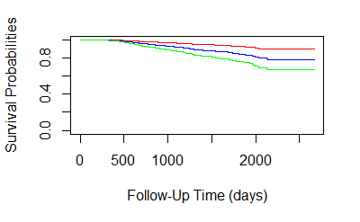

```r
plot(surv_probs_Cox, col = c("red", "blue", "green"),
     xlab = "Follow-Up Time (days)", ylab = "Survival Probabilities")
```

```r
task_gbcs = TaskSurv$new(id = "train_gbcs", backend = train_gbcs, time = "survtime", event = "censdead")
test_gbcs = TaskSurv$new(id = "test_gbcs", backend = test_gbcs, time = "survtime", event = "censdead")

learner.cox = lrn("surv.coxph")
learner.cox$train(task_gbcs)
learner.cox$model
```

```
Call:
survival::coxph(formula = task$formula(), data = task$data(),
    x = TRUE)

               coef exp(coef) se(coef)      z        p
age         0.15550   1.16825  0.14199  1.095  0.27345
estrg_recp  0.05275   1.05416  0.11275  0.468  0.63990
grade1     -1.28643   0.27626  0.48423 -2.657  0.00789
grade2     -0.48236   0.61732  0.19292 -2.500  0.01241
grade3           NA        NA  0.00000     NA       NA
hormone    -0.22560   0.79804  0.19050 -1.184  0.23631
menopause  -0.17756   0.83731  0.29747 -0.597  0.55058
nodes       0.29402   1.34182  0.05827  5.046 4.51e-07
prog_recp  -1.01213   0.36345  0.25477 -3.973 7.11e-05
size        0.22094   1.24725  0.07416  2.979  0.00289

Likelihood ratio test=96.67  on 9 df, p=< 2.2e-16
n= 548, number of events= 132
```

```r
prediction.cox = learner.cox$predict(test_gbcs)
prediction.cox
```

```
<PredictionSurv> for 138 observations:
```

| row_ids | time | status | crank | lp | distr |
| --- | --- | --- | --- | --- | --- |
| 1 | 2282 | FALSE | 0.116127251 | 0.116127251 |  |
| 2 | 1456 | TRUE | -1.668454664 | -1.668454664 |  |
| 3 | 2563 | FALSE | 0.240345723 | 0.240345723 |  |
| 4 | 2450 | TRUE | 0.409955571 | 0.409955571 |  |
| 5 | 1722 | FALSE | -0.255517441 | -0.255517441 |  |
| 6 | 1889 | TRUE | 0.410439783 | 0.410439783 |  |
| 7 | 436 | TRUE | 0.508781645 | 0.508781645 |  |
| 8 | 1955 | TRUE | 0.918262378 | 0.918262378 |  |
| 9 | 1058 | TRUE | 1.565037498 | 1.565037498 |  |
| 10 | 1855 | FALSE | 0.512463365 | 0.512463365 |  |

[output cut: 128 more lines]

```r
prediction.cox$score()
```

```
surv.harrell_c
     0.6897718
```

```r
measure = lapply(c("surv.graf"), msr)
```

```
The default of 'proper' will be changed to 'TRUE' in v0.6.0.
```

```r
prediction.cox$score(measure)
```

```
surv.graf
0.1326272
```

### Support-Vector Machine

```r
svm$model
```

```
survivalsvm result

Call:

 survivalsvm::survivalsvm(formula = task$formula(), data = task$data(), gamma.mu = 1, kernel = "lin_kernel", opt.meth = "ipop")

Survival svm approach              : regression
Type of Kernel                     : lin_kernel
Optimization solver used           : ipop
Number of support vectors retained : 548
survivalsvm version                : 0.0.5
```

At the heart of mlr3tuning are the R6 classes: * **TuningInstanceSingleCrit, TuningInstanceMultiCrit** : These two classes describe the tuning problem and store the results. * **Tuner**: This class is the base class for implementations of tuning algorithms.

```r
svm.pred <- svm$predict(test_gbcs)
svm.pred$score()
```

```
surv.harrell_c
     0.6534235
```

```r
svm$param_set
```

```
<ParamSet>
```

| id | class | lower | upper | nlevels | default | parents | value |
| --- | --- | --- | --- | --- | --- | --- | --- |
| bound | ParamDbl | 0 | Inf | Inf |  |  |  |
| conv.tol | ParamDbl | 0 | Inf | Inf |  |  |  |
| diff.meth | ParamFct | NA | NA | 3 |  |  |  |
| eig.tol | ParamDbl | 0 | Inf | Inf |  |  |  |
| gamma.mu | ParamUty | NA | NA | Inf |  |  |  |
| kernel | ParamFct | NA | NA | 4 |  |  |  |
| kernel.pars | ParamUty | NA | NA | Inf |  |  |  |
| margin | ParamDbl | 0 | Inf | Inf |  |  |  |
| maxiter | ParamInt | 0 | Inf | Inf |  |  |  |
| opt.meth | ParamFct | NA | NA | 2 |  |  |  |

[output cut: 4 more lines]

Here, we opt to tune parameter **gamma.mu** as a double value (x.xx) in the set 0.01 and 1.

```r
search_space = ps(gamma.mu = p_dbl(lower = 0.01, upper = 1))
search_space
```

```
<ParamSet>
```

| id | class | lower | upper | nlevels | default | value |
| --- | --- | --- | --- | --- | --- | --- |
| gamma.mu | ParamDbl | 0.01 | 1 | Inf |  |  |

Next, we need to specify how to evaluate the performance. For this, we need to choose a resampling strategy

```r
hout = rsmp("holdout")
```

[output not shown]

and the performance measure

```r
measure = msr("surv.cindex")
```

Finally, one has to select the budget available, to solve this tuning instance. This is done by selecting one of the available Terminators. We decided to set : terminate after 8 iteration to same computational costs with respect to a potential gain in performance.

```r
evals8 = trm("evals", n_evals = 8)

instance = TuningInstanceSingleCrit$new(
  task = task_gbcs,
  learner = svm,
  resampling = hout,
  measure = measure,
  search_space = search_space,
  terminator = evals8
)
#Type of optimization
tuner = tnr("grid_search", resolution = 10)
```

Through the Tuner R6 class we trigger the tuner. To start the tuning, we simply pass the TuningInstanceSingleCrit to the $optimize() method of the initialized Tuner. The tuner proceeds as follows

```r
tuner$optimize(instance)
```

```
INFO  [16:41:50.085] [bbotk] Starting to optimize 1 parameter(s) with '<OptimizerGridSearch>' and '<TerminatorEvals> [n_evals=8]'
INFO  [16:41:50.173] [bbotk] Evaluating 1 configuration(s)
INFO  [16:41:50.302] [mlr3]  Running benchmark with 1 resampling iterations
INFO  [16:41:50.652] [mlr3]  Applying learner 'surv.svm' on task 'train_gbcs' (iter 1/1)
```

```
INFO  [16:41:56.963] [mlr3]  Finished benchmark
INFO  [16:41:57.460] [bbotk] Result of batch 1:
```

| gamma.mu | surv.harrell_c | uhash |
| --- | --- | --- |
| 0.12 | 0.7162162 | 3ac95782-afd3-46cc-b0a0-d0fd32a50747 |

```
INFO  [16:41:57.625] [bbotk]
INFO  [16:41:57.653] [bbotk] Evaluating 1 configuration(s)
INFO  [16:41:57.788] [mlr3]  Running benchmark with 1 resampling iterations
INFO  [16:41:57.844] [mlr3]  Applying learner 'surv.svm' on task 'train_gbcs' (iter 1/1)
```

```
INFO  [16:42:07.393] [mlr3]  Finished benchmark
INFO  [16:42:07.486] [bbotk] Result of batch 2:
```

| gamma.mu | surv.harrell_c | uhash |
| --- | --- | --- |
| 1 | 0.7225225 | b7fa63c6-5e05-42d1-b1e5-7ce989cb7223 |

```
INFO  [16:42:07.499] [bbotk]
INFO  [16:42:07.507] [bbotk] Evaluating 1 configuration(s)
INFO  [16:42:07.596] [mlr3]  Running benchmark with 1 resampling iterations
INFO  [16:42:07.623] [mlr3]  Applying learner 'surv.svm' on task 'train_gbcs' (iter 1/1)
```

```
INFO  [16:42:13.526] [mlr3]  Finished benchmark
INFO  [16:42:13.630] [bbotk] Result of batch 3:
```

| gamma.mu | surv.harrell_c | uhash |
| --- | --- | --- |
| 0.67 | 0.7210811 | d58dce56-5644-49f2-9032-5f1d87411097 |

```
INFO  [16:42:13.640] [bbotk]
INFO  [16:42:13.648] [bbotk] Evaluating 1 configuration(s)
INFO  [16:42:13.703] [mlr3]  Running benchmark with 1 resampling iterations
INFO  [16:42:13.749] [mlr3]  Applying learner 'surv.svm' on task 'train_gbcs' (iter 1/1)
```

```
INFO  [16:42:19.253] [mlr3]  Finished benchmark
INFO  [16:42:19.342] [bbotk] Result of batch 4:
```

| gamma.mu | surv.harrell_c | uhash |
| --- | --- | --- |
| 0.89 | 0.721982 | ce1264c7-263c-4a21-8582-b7bc18c1f83b |

```
INFO  [16:42:19.356] [bbotk]
INFO  [16:42:19.362] [bbotk] Evaluating 1 configuration(s)
INFO  [16:42:19.410] [mlr3]  Running benchmark with 1 resampling iterations
INFO  [16:42:19.431] [mlr3]  Applying learner 'surv.svm' on task 'train_gbcs' (iter 1/1)
```

```
INFO  [16:42:24.586] [mlr3]  Finished benchmark
INFO  [16:42:24.677] [bbotk] Result of batch 5:
```

| gamma.mu | surv.harrell_c | uhash |
| --- | --- | --- |
| 0.34 | 0.7163964 | 36fc2dee-5266-4715-a085-38bfca907eee |

```
INFO  [16:42:24.688] [bbotk]
INFO  [16:42:24.696] [bbotk] Evaluating 1 configuration(s)
INFO  [16:42:24.761] [mlr3]  Running benchmark with 1 resampling iterations
INFO  [16:42:24.783] [mlr3]  Applying learner 'surv.svm' on task 'train_gbcs' (iter 1/1)
```

```
INFO  [16:42:29.892] [mlr3]  Finished benchmark
INFO  [16:42:29.982] [bbotk] Result of batch 6:
```

| gamma.mu | surv.harrell_c | uhash |
| --- | --- | --- |
| 0.23 | 0.716036 | 292b0a68-b664-4c8b-94a7-c186a931fce6 |

```
INFO  [16:42:29.993] [bbotk]
INFO  [16:42:29.999] [bbotk] Evaluating 1 configuration(s)
INFO  [16:42:30.084] [mlr3]  Running benchmark with 1 resampling iterations
INFO  [16:42:30.105] [mlr3]  Applying learner 'surv.svm' on task 'train_gbcs' (iter 1/1)
```

```
INFO  [16:42:35.662] [mlr3]  Finished benchmark
INFO  [16:42:35.753] [bbotk] Result of batch 7:
```

| gamma.mu | surv.harrell_c | uhash |
| --- | --- | --- |
| 0.78 | 0.7181982 | f57ce203-0699-4608-b7b3-b3f51d5424a6 |

```
INFO  [16:42:35.764] [bbotk]
INFO  [16:42:35.773] [bbotk] Evaluating 1 configuration(s)
INFO  [16:42:35.831] [mlr3]  Running benchmark with 1 resampling iterations
INFO  [16:42:35.857] [mlr3]  Applying learner 'surv.svm' on task 'train_gbcs' (iter 1/1)
```

```
INFO  [16:42:41.490] [mlr3]  Finished benchmark
INFO  [16:42:41.599] [bbotk] Result of batch 8:
```

| gamma.mu | surv.harrell_c | uhash |
| --- | --- | --- |
| 0.45 | 0.7192793 | bf50bcb4-f75d-4cbe-ba63-b3b37fb3c504 |

```
INFO  [16:42:41.610] [bbotk]
INFO  [16:42:41.628] [bbotk] Finished optimizing after 8 evaluation(s)
INFO  [16:42:41.634] [bbotk] Result:
```

| gamma.mu | learner_param_vals | x_domain | surv.harrell_c |
| --- | --- | --- | --- |
| 1 |  |  | 0.7225225 |

```
INFO  [16:42:41.646] [bbotk]
```

| gamma.mu | learner_param_vals | x_domain | surv.harrell_c |
| --- | --- | --- | --- |
| 1 |  |  | 0.7225225 |

```r
print(instance$result_learner_param_vals)
```

[output not shown]

We obtain the best performanc e result

```r
print(instance$result_y)
```

[output not shown]

However, one can investigate all resamplings which were undertaken, as they are stored in the archive of the TuningInstanceSingleCrit and can be accessed by using as.data.table()

| gamma.mu | surv.harrell_c | uhash | timestamp | batch_nr | x_domain_gamma.mu |
| --- | --- | --- | --- | --- | --- |
| 0.12 | 0.7162162 | 3ac95782-afd3-46cc-b0a0-d0fd32a50747 | 2021-05-31 16:41:57 | 1 | 0.12 |
| 1.00 | 0.7225225 | b7fa63c6-5e05-42d1-b1e5-7ce989cb7223 | 2021-05-31 16:42:07 | 2 | 1.00 |
| 0.67 | 0.7210811 | d58dce56-5644-49f2-9032-5f1d87411097 | 2021-05-31 16:42:13 | 3 | 0.67 |
| 0.89 | 0.7219820 | ce1264c7-263c-4a21-8582-b7bc18c1f83b | 2021-05-31 16:42:19 | 4 | 0.89 |
| 0.34 | 0.7163964 | 36fc2dee-5266-4715-a085-38bfca907eee | 2021-05-31 16:42:24 | 5 | 0.34 |
| 0.23 | 0.7160360 | 292b0a68-b664-4c8b-94a7-c186a931fce6 | 2021-05-31 16:42:29 | 6 | 0.23 |
| 0.78 | 0.7181982 | f57ce203-0699-4608-b7b3-b3f51d5424a6 | 2021-05-31 16:42:35 | 7 | 0.78 |
| 0.45 | 0.7192793 | bf50bcb4-f75d-4cbe-ba63-b3b37fb3c504 | 2021-05-31 16:42:41 | 8 | 0.45 |

Now the optimized hyperparameters can take the previously created Learner, set the returned hyperparameters and train it on the full dataset (follows).

```r
#Setting the best parameters to the learner
svm$param_set$values = instance$result_learner_param_vals
#Retraining the learner
svm$train(task_gbcs)
```

```r
svm$train(task_gbcs)
```

The trained model can now be used to make a prediction on external data. Note that predicting on observations present in the task, should be avoided. The model has seen these observations already during tuning and therefore results would be statistically biased. Hence, the resulting performance measure would be over-optimistic. Instead, to get statistically unbiased performance estimates for the current task, nested resampling is required.

Then we train the model so we can use the learner like any other learner, calling the $train()

```r
svm$model
```

```
survivalsvm result

Call:

 survivalsvm::survivalsvm(formula = task$formula(), data = task$data(), gamma.mu = 1, kernel = "lin_kernel", opt.meth = "ipop")

Survival svm approach              : regression
Type of Kernel                     : lin_kernel
Optimization solver used           : ipop
Number of support vectors retained : 548
survivalsvm version                : 0.0.5
```

and the $predict() method.

```r
svm.pred <- svm$predict(test_gbcs)
svm.pred$score()
```

```
surv.harrell_c
     0.6534235
```

### Random Forest

```r
install.packages('ranger')
library(ranger)
library("mlr3verse")
```

```r
rf <-lrn("surv.ranger")
rf$train(task_gbcs)
rf$oob_error()
```

```
[1] 0.2991005
```

```r
rf$model
```

```
Ranger result

Call:
 ranger::ranger(formula = NULL, dependent.variable.name = targets[1L],      status.variable.name = targets[2L], data = task$data(), case.weights = task$weights$weight,      num.threads = 1L)

Type:                             Survival
Number of trees:                  500
Sample size:                      548
Number of independent variables:  10
Mtry:                             4
Target node size:                 3
Variable importance mode:         none
Splitrule:                        logrank
Number of unique death times:     467
OOB prediction error (1-C):       0.2991005
```

```r
rf.pred <- rf$predict(test_gbcs)
rf.pred$score()
```

```
surv.harrell_c
     0.7010425
```

```r
rf$param_set
```

```
<ParamSet>
```

| id | class | lower | upper | nlevels | default | value |
| --- | --- | --- | --- | --- | --- | --- |
| num.trees | ParamInt | 1 | Inf | Inf |  |  |
| mtry | ParamInt | 1 | Inf | Inf |  |  |
| importance | ParamFct | NA | NA | 4 |  |  |
| write.forest | ParamLgl | NA | NA | 2 |  |  |
| min.node.size | ParamInt | 1 | Inf | Inf |  |  |
| replace | ParamLgl | NA | NA | 2 |  |  |
| sample.fraction | ParamDbl | 0 | 1 | Inf |  |  |
| splitrule | ParamFct | NA | NA | 4 |  |  |
| num.random.splits | ParamInt | 1 | Inf | Inf |  |  |
| max.depth | ParamInt | -Inf | Inf | Inf |  |  |

[output cut: 15 more lines]

```r
search_space = ps(
  min.node.size = p_int(lower = 1, upper = 6),
  mtry = p_int(lower = 2, upper = 10),
  sample.fraction = p_dbl(lower = 0.5, upper = 0.7)
  )

search_space
```

We use as ressampling strategy a cross validation with 5 folds

```r
search_space
```

```
<ParamSet>
```

| id | class | lower | upper | nlevels | default | value |
| --- | --- | --- | --- | --- | --- | --- |
| min.node.size | ParamInt | 1.0 | 6.0 | 6 |  |  |
| mtry | ParamInt | 2.0 | 10.0 | 9 |  |  |
| sample.fraction | ParamDbl | 0.5 | 0.7 | Inf |  |  |

```r
#Resampling Strategy
hout = rsmp("cv", folds = 5)
#Performance measure (same used by professor)
measure = msr("surv.cindex")
#Termination Strategy
evalsTerm = trm("stagnation")
```

```r
measure = msr("surv.cindex")
```

```r
evalsTerm = trm("stagnation")
```

```r
instance = TuningInstanceSingleCrit$new(
  task = task_gbcs,
  learner = rf,
  resampling = hout,
  measure = measure,
  search_space = search_space,
  terminator = evalsTerm
)
```

```r
#Type of optimization
tuner = tnr("grid_search", resolution = 5)
#Start the tuning
tuner$optimize(instance)
```

```
INFO  [16:57:05.327] [bbotk] Starting to optimize 3 parameter(s) with '<OptimizerGridSearch>' and '<TerminatorStagnation> [iters=10, threshold=0]'
INFO  [16:57:05.397] [bbotk] Evaluating 1 configuration(s)
INFO  [16:57:05.549] [mlr3]  Running benchmark with 5 resampling iterations
```

```
INFO  [16:57:05.992] [mlr3]  Applying learner 'surv.ranger' on task 'train_gbcs' (iter 4/5)
INFO  [16:57:13.723] [mlr3]  Applying learner 'surv.ranger' on task 'train_gbcs' (iter 2/5)
INFO  [16:57:22.550] [mlr3]  Applying learner 'surv.ranger' on task 'train_gbcs' (iter 3/5)
INFO  [16:57:29.729] [mlr3]  Applying learner 'surv.ranger' on task 'train_gbcs' (iter 5/5)
INFO  [16:57:36.676] [mlr3]  Applying learner 'surv.ranger' on task 'train_gbcs' (iter 1/5)
INFO  [16:57:43.495] [mlr3]  Finished benchmark
INFO  [16:57:43.651] [bbotk] Result of batch 1:
```

| min.node.size | mtry | sample.fraction | surv.harrell_c | uhash |
| --- | --- | --- | --- | --- |
| 6 | 8 | 0.7 | 0.716255 | b6c8cb9d-3b02-45e0-a5b7-6d896e0da8e5 |

```
INFO  [16:57:43.667] [bbotk]
INFO  [16:57:43.673] [bbotk] Evaluating 1 configuration(s)
INFO  [16:57:43.759] [mlr3]  Running benchmark with 5 resampling iterations
INFO  [16:57:43.775] [mlr3]  Applying learner 'surv.ranger' on task 'train_gbcs' (iter 2/5)
INFO  [16:57:49.602] [mlr3]  Applying learner 'surv.ranger' on task 'train_gbcs' (iter 3/5)
INFO  [16:57:54.744] [mlr3]  Applying learner 'surv.ranger' on task 'train_gbcs' (iter 4/5)
INFO  [16:58:00.359] [mlr3]  Applying learner 'surv.ranger' on task 'train_gbcs' (iter 5/5)
INFO  [16:58:06.322] [mlr3]  Applying learner 'surv.ranger' on task 'train_gbcs' (iter 1/5)
INFO  [16:58:11.527] [mlr3]  Finished benchmark
INFO  [16:58:11.649] [bbotk] Result of batch 2:
```

| min.node.size | mtry | sample.fraction | surv.harrell_c | uhash |
| --- | --- | --- | --- | --- |
| 5 | 4 | 0.5 | 0.7303859 | 217a1714-d23d-4a38-80e1-6535f0bfd5c9 |

```
INFO  [16:58:11.665] [bbotk]
INFO  [16:58:11.672] [bbotk] Evaluating 1 configuration(s)
INFO  [16:58:11.740] [mlr3]  Running benchmark with 5 resampling iterations
INFO  [16:58:11.761] [mlr3]  Applying learner 'surv.ranger' on task 'train_gbcs' (iter 4/5)
INFO  [16:58:18.205] [mlr3]  Applying learner 'surv.ranger' on task 'train_gbcs' (iter 2/5)
INFO  [16:58:24.559] [mlr3]  Applying learner 'surv.ranger' on task 'train_gbcs' (iter 5/5)
INFO  [16:58:30.292] [mlr3]  Applying learner 'surv.ranger' on task 'train_gbcs' (iter 1/5)
INFO  [16:58:36.150] [mlr3]  Applying learner 'surv.ranger' on task 'train_gbcs' (iter 3/5)
INFO  [16:58:42.333] [mlr3]  Finished benchmark
INFO  [16:58:42.444] [bbotk] Result of batch 3:
```

| min.node.size | mtry | sample.fraction | surv.harrell_c | uhash |
| --- | --- | --- | --- | --- |
| 2 | 4 | 0.5 | 0.715824 | 40b77861-eaf2-405a-91c1-955d87ecd55e |

```
INFO  [16:58:42.457] [bbotk]
INFO  [16:58:42.468] [bbotk] Evaluating 1 configuration(s)
INFO  [16:58:42.545] [mlr3]  Running benchmark with 5 resampling iterations
INFO  [16:58:42.574] [mlr3]  Applying learner 'surv.ranger' on task 'train_gbcs' (iter 4/5)
INFO  [16:58:51.402] [mlr3]  Applying learner 'surv.ranger' on task 'train_gbcs' (iter 2/5)
INFO  [16:59:00.327] [mlr3]  Applying learner 'surv.ranger' on task 'train_gbcs' (iter 5/5)
INFO  [16:59:09.869] [mlr3]  Applying learner 'surv.ranger' on task 'train_gbcs' (iter 1/5)
INFO  [16:59:19.027] [mlr3]  Applying learner 'surv.ranger' on task 'train_gbcs' (iter 3/5)
INFO  [16:59:28.053] [mlr3]  Finished benchmark
INFO  [16:59:28.193] [bbotk] Result of batch 4:
```

| min.node.size | mtry | sample.fraction | surv.harrell_c | uhash |
| --- | --- | --- | --- | --- |
| 1 | 8 | 0.7 | 0.7014711 | 490dd749-e2c1-4667-acb6-e675e6e6e58d |

```
INFO  [16:59:28.207] [bbotk]
INFO  [16:59:28.213] [bbotk] Evaluating 1 configuration(s)
INFO  [16:59:28.285] [mlr3]  Running benchmark with 5 resampling iterations
INFO  [16:59:28.305] [mlr3]  Applying learner 'surv.ranger' on task 'train_gbcs' (iter 4/5)
INFO  [16:59:36.312] [mlr3]  Applying learner 'surv.ranger' on task 'train_gbcs' (iter 2/5)
INFO  [16:59:43.250] [mlr3]  Applying learner 'surv.ranger' on task 'train_gbcs' (iter 3/5)
INFO  [16:59:50.396] [mlr3]  Applying learner 'surv.ranger' on task 'train_gbcs' (iter 5/5)
INFO  [16:59:58.406] [mlr3]  Applying learner 'surv.ranger' on task 'train_gbcs' (iter 1/5)
INFO  [17:00:05.808] [mlr3]  Finished benchmark
INFO  [17:00:05.926] [bbotk] Result of batch 5:
```

| min.node.size | mtry | sample.fraction | surv.harrell_c | uhash |
| --- | --- | --- | --- | --- |
| 5 | 10 | 0.6 | 0.7133877 | dc55f7c3-c36d-46b1-ada4-16ccb99ee92e |

```
INFO  [17:00:05.938] [bbotk]
INFO  [17:00:05.945] [bbotk] Evaluating 1 configuration(s)
INFO  [17:00:06.016] [mlr3]  Running benchmark with 5 resampling iterations
INFO  [17:00:06.041] [mlr3]  Applying learner 'surv.ranger' on task 'train_gbcs' (iter 2/5)
INFO  [17:00:13.132] [mlr3]  Applying learner 'surv.ranger' on task 'train_gbcs' (iter 1/5)
INFO  [17:00:19.786] [mlr3]  Applying learner 'surv.ranger' on task 'train_gbcs' (iter 4/5)
INFO  [17:00:26.136] [mlr3]  Applying learner 'surv.ranger' on task 'train_gbcs' (iter 3/5)
INFO  [17:00:32.449] [mlr3]  Applying learner 'surv.ranger' on task 'train_gbcs' (iter 5/5)
INFO  [17:00:39.731] [mlr3]  Finished benchmark
INFO  [17:00:39.883] [bbotk] Result of batch 6:
```

| min.node.size | mtry | sample.fraction | surv.harrell_c | uhash |
| --- | --- | --- | --- | --- |
| 1 | 4 | 0.55 | 0.7088648 | 0be4a752-76b1-424e-89fe-949aaa8e2337 |

```
INFO  [17:00:39.899] [bbotk]
INFO  [17:00:39.911] [bbotk] Evaluating 1 configuration(s)
INFO  [17:00:40.004] [mlr3]  Running benchmark with 5 resampling iterations
INFO  [17:00:40.103] [mlr3]  Applying learner 'surv.ranger' on task 'train_gbcs' (iter 2/5)
INFO  [17:00:48.668] [mlr3]  Applying learner 'surv.ranger' on task 'train_gbcs' (iter 1/5)
INFO  [17:00:57.011] [mlr3]  Applying learner 'surv.ranger' on task 'train_gbcs' (iter 4/5)
INFO  [17:01:05.904] [mlr3]  Applying learner 'surv.ranger' on task 'train_gbcs' (iter 3/5)
INFO  [17:01:13.868] [mlr3]  Applying learner 'surv.ranger' on task 'train_gbcs' (iter 5/5)
INFO  [17:01:20.757] [mlr3]  Finished benchmark
INFO  [17:01:20.880] [bbotk] Result of batch 7:
```

| min.node.size | mtry | sample.fraction | surv.harrell_c | uhash |
| --- | --- | --- | --- | --- |
| 3 | 8 | 0.5 | 0.7097905 | 337229f2-d6ad-4fe8-ba7e-17f9031f3189 |

```
INFO  [17:01:20.894] [bbotk]
INFO  [17:01:20.902] [bbotk] Evaluating 1 configuration(s)
INFO  [17:01:20.980] [mlr3]  Running benchmark with 5 resampling iterations
INFO  [17:01:21.013] [mlr3]  Applying learner 'surv.ranger' on task 'train_gbcs' (iter 5/5)
INFO  [17:01:27.257] [mlr3]  Applying learner 'surv.ranger' on task 'train_gbcs' (iter 1/5)
INFO  [17:01:34.038] [mlr3]  Applying learner 'surv.ranger' on task 'train_gbcs' (iter 3/5)
INFO  [17:01:39.813] [mlr3]  Applying learner 'surv.ranger' on task 'train_gbcs' (iter 4/5)
INFO  [17:01:46.104] [mlr3]  Applying learner 'surv.ranger' on task 'train_gbcs' (iter 2/5)
INFO  [17:01:51.852] [mlr3]  Finished benchmark
INFO  [17:01:51.975] [bbotk] Result of batch 8:
```

| min.node.size | mtry | sample.fraction | surv.harrell_c | uhash |
| --- | --- | --- | --- | --- |
| 6 | 4 | 0.7 | 0.7295716 | aec2a332-4772-4948-bf24-cf14346cac70 |

```
INFO  [17:01:51.991] [bbotk]
INFO  [17:01:51.998] [bbotk] Evaluating 1 configuration(s)
INFO  [17:01:52.104] [mlr3]  Running benchmark with 5 resampling iterations
INFO  [17:01:52.151] [mlr3]  Applying learner 'surv.ranger' on task 'train_gbcs' (iter 3/5)
INFO  [17:01:59.137] [mlr3]  Applying learner 'surv.ranger' on task 'train_gbcs' (iter 5/5)
INFO  [17:02:05.390] [mlr3]  Applying learner 'surv.ranger' on task 'train_gbcs' (iter 1/5)
INFO  [17:02:11.645] [mlr3]  Applying learner 'surv.ranger' on task 'train_gbcs' (iter 2/5)
INFO  [17:02:17.772] [mlr3]  Applying learner 'surv.ranger' on task 'train_gbcs' (iter 4/5)
INFO  [17:02:24.325] [mlr3]  Finished benchmark
INFO  [17:02:24.441] [bbotk] Result of batch 9:
```

| min.node.size | mtry | sample.fraction | surv.harrell_c | uhash |
| --- | --- | --- | --- | --- |
| 6 | 6 | 0.65 | 0.7230077 | 71fbd864-aafb-42ac-8243-61c4c604eb6b |

```
INFO  [17:02:24.455] [bbotk]
INFO  [17:02:24.462] [bbotk] Evaluating 1 configuration(s)
INFO  [17:02:24.528] [mlr3]  Running benchmark with 5 resampling iterations
INFO  [17:02:24.550] [mlr3]  Applying learner 'surv.ranger' on task 'train_gbcs' (iter 4/5)
INFO  [17:02:32.066] [mlr3]  Applying learner 'surv.ranger' on task 'train_gbcs' (iter 1/5)
INFO  [17:02:38.972] [mlr3]  Applying learner 'surv.ranger' on task 'train_gbcs' (iter 2/5)
INFO  [17:02:46.299] [mlr3]  Applying learner 'surv.ranger' on task 'train_gbcs' (iter 3/5)
INFO  [17:02:53.354] [mlr3]  Applying learner 'surv.ranger' on task 'train_gbcs' (iter 5/5)
INFO  [17:03:00.650] [mlr3]  Finished benchmark
INFO  [17:03:00.769] [bbotk] Result of batch 10:
```

| min.node.size | mtry | sample.fraction | surv.harrell_c | uhash |
| --- | --- | --- | --- | --- |
| 3 | 6 | 0.65 | 0.7111926 | 8b04bcd5-9132-4899-93f6-aaab034a3dfb |

```
INFO  [17:03:00.782] [bbotk]
INFO  [17:03:00.789] [bbotk] Evaluating 1 configuration(s)
INFO  [17:03:00.869] [mlr3]  Running benchmark with 5 resampling iterations
INFO  [17:03:00.891] [mlr3]  Applying learner 'surv.ranger' on task 'train_gbcs' (iter 4/5)
INFO  [17:03:09.308] [mlr3]  Applying learner 'surv.ranger' on task 'train_gbcs' (iter 2/5)
INFO  [17:03:16.511] [mlr3]  Applying learner 'surv.ranger' on task 'train_gbcs' (iter 5/5)
INFO  [17:03:23.912] [mlr3]  Applying learner 'surv.ranger' on task 'train_gbcs' (iter 3/5)
INFO  [17:03:31.544] [mlr3]  Applying learner 'surv.ranger' on task 'train_gbcs' (iter 1/5)
INFO  [17:03:39.471] [mlr3]  Finished benchmark
INFO  [17:03:39.595] [bbotk] Result of batch 11:
```

| min.node.size | mtry | sample.fraction | surv.harrell_c | uhash |
| --- | --- | --- | --- | --- |
| 6 | 10 | 0.7 | 0.7196365 | 51bbc83e-f6f0-4111-8174-265cada3a3dc |

```
INFO  [17:03:39.607] [bbotk]
INFO  [17:03:39.619] [bbotk] Evaluating 1 configuration(s)
INFO  [17:03:39.694] [mlr3]  Running benchmark with 5 resampling iterations
INFO  [17:03:39.720] [mlr3]  Applying learner 'surv.ranger' on task 'train_gbcs' (iter 4/5)
INFO  [17:03:45.757] [mlr3]  Applying learner 'surv.ranger' on task 'train_gbcs' (iter 2/5)
INFO  [17:03:50.746] [mlr3]  Applying learner 'surv.ranger' on task 'train_gbcs' (iter 3/5)
INFO  [17:03:57.086] [mlr3]  Applying learner 'surv.ranger' on task 'train_gbcs' (iter 5/5)
INFO  [17:04:02.137] [mlr3]  Applying learner 'surv.ranger' on task 'train_gbcs' (iter 1/5)
INFO  [17:04:09.000] [mlr3]  Finished benchmark
INFO  [17:04:09.153] [bbotk] Result of batch 12:
```

| min.node.size | mtry | sample.fraction | surv.harrell_c | uhash |
| --- | --- | --- | --- | --- |
| 5 | 4 | 0.55 | 0.7269135 | f8070db3-5ff0-4204-b881-086c8d269116 |

```
INFO  [17:04:09.170] [bbotk]
INFO  [17:04:09.188] [bbotk] Finished optimizing after 12 evaluation(s)
INFO  [17:04:09.193] [bbotk] Result:
```

| min.node.size | mtry | sample.fraction | learner_param_vals | x_domain | surv.harrell_c |
| --- | --- | --- | --- | --- | --- |
| 5 | 4 | 0.5 |  |  | 0.7303859 |

```
INFO  [17:04:09.208] [bbotk]
```

| min.node.size | mtry | sample.fraction | learner_param_vals | x_domain | surv.harrell_c |
| --- | --- | --- | --- | --- | --- |
| 5 | 4 | 0.5 |  |  | 0.7303859 |

```r
#Best parameters
instance$result_learner_param_vals
```

```
$num.threads
[1] 1

$min.node.size
[1] 5

$mtry
[1] 4

$sample.fraction
[1] 0.5
```

```r
#Best performance
instance$result_y
```

```
surv.harrell_c
     0.7303859
```

```r
#Archive of the tuning
as.data.table(instance$archive)
```

| min.node.size | mtry | sample.fraction | surv.harrell_c | uhash | timestamp | batch_nr | x_domain_min.node.size | x_domain_mtry | x_domain_sample.fraction |
| --- | --- | --- | --- | --- | --- | --- | --- | --- | --- |
| 6 | 8 | 0.70 | 0.7162550 | b6c8cb9d-3b02-45e0-a5b7-6d896e0da8e5 | 2021-05-31 16:57:43 | 1 | 6 | 8 | 0.70 |
| 5 | 4 | 0.50 | 0.7303859 | 217a1714-d23d-4a38-80e1-6535f0bfd5c9 | 2021-05-31 16:58:11 | 2 | 5 | 4 | 0.50 |
| 2 | 4 | 0.50 | 0.7158240 | 40b77861-eaf2-405a-91c1-955d87ecd55e | 2021-05-31 16:58:42 | 3 | 2 | 4 | 0.50 |
| 1 | 8 | 0.70 | 0.7014711 | 490dd749-e2c1-4667-acb6-e675e6e6e58d | 2021-05-31 16:59:28 | 4 | 1 | 8 | 0.70 |
| 5 | 10 | 0.60 | 0.7133877 | dc55f7c3-c36d-46b1-ada4-16ccb99ee92e | 2021-05-31 17:00:05 | 5 | 5 | 10 | 0.60 |
| 1 | 4 | 0.55 | 0.7088648 | 0be4a752-76b1-424e-89fe-949aaa8e2337 | 2021-05-31 17:00:39 | 6 | 1 | 4 | 0.55 |
| 3 | 8 | 0.50 | 0.7097905 | 337229f2-d6ad-4fe8-ba7e-17f9031f3189 | 2021-05-31 17:01:20 | 7 | 3 | 8 | 0.50 |
| 6 | 4 | 0.70 | 0.7295716 | aec2a332-4772-4948-bf24-cf14346cac70 | 2021-05-31 17:01:51 | 8 | 6 | 4 | 0.70 |
| 6 | 6 | 0.65 | 0.7230077 | 71fbd864-aafb-42ac-8243-61c4c604eb6b | 2021-05-31 17:02:24 | 9 | 6 | 6 | 0.65 |
| 3 | 6 | 0.65 | 0.7111926 | 8b04bcd5-9132-4899-93f6-aaab034a3dfb | 2021-05-31 17:03:00 | 10 | 3 | 6 | 0.65 |

[output cut: 2 more lines]

```r
NA
```

```r
#Setting the best parameters to the learner
rf$param_set$values = instance$result_learner_param_vals
#Retraining the learner
rf$train(task_gbcs)
```

```r
rf$oob_error()
```

```
[1] 0.2753094
```

```r
#Prediction Accuracy (0.7244294)
rf$model
```

```
Ranger result

Call:
 ranger::ranger(formula = NULL, dependent.variable.name = targets[1L],      status.variable.name = targets[2L], data = task$data(), case.weights = task$weights$weight,      num.threads = 1L, min.node.size = 5L, mtry = 4L, sample.fraction = 0.5)

Type:                             Survival
Number of trees:                  500
Sample size:                      548
Number of independent variables:  10
Mtry:                             4
Target node size:                 5
Variable importance mode:         none
Splitrule:                        logrank
Number of unique death times:     467
OOB prediction error (1-C):       0.2753094
```

```r
rf.pred <- rf$predict(test_gbcs)
rf.pred$score()
```

```
surv.harrell_c
     0.7103409
```